# Data Science for Psychologists (ds4psy)

Hansjörg Neth, SPDS, uni.kn

2019 05 03

# Course Coordinates

- PSY-15150, at the [University of Konstanz](https://www.uni-konstanz.de/) by [Hansjörg Neth](http://neth.de/) (h.neth@uni.kn, [SPDS](https://www.spds.uni-konstanz.de/), office D507).
- Summer 2019: Mondays, 15:15–16:45, D435.
- Links to current [course syllabus](http://rpository.com/ds4psy/) | [ZeUS](https://zeus.uni-konstanz.de:443/hioserver/pages/startFlow.xhtml?_flowId=detailView-flow&unitId=5101&periodId=179&navigationPosition=hisinoneLehrorganisation,examEventOverviewOwn) | [Ilias](https://ilias.uni-konstanz.de/ilias/goto_ilias_uni_crs_863036.html)
- Essentials and WPAs at https://bookdown.org/hneth/ds4psy/.

# Course Description

## Overview

This course provides an introduction to [R](http://www.r-project.org/) and conveys fundamental skills of data literacy and the basics of data science. It is suited for beginners and experienced students and contains 3 parts:

1. First, we introduce key concepts and commands of the [R](http://www.r-project.org/) programming language for statistical computing. This includes working with the [R Studio](http://www.rstudio.com/) environment and writing reproducible research documents with [R Markdown](https://rmarkdown.rstudio.com/).
2. By working with different forms and types of data, the course provides a basic introduction to *data literacy*. Although later sessions add elements of *computer programming* (e.g., writing functions and loops), our focus remains on making sense of data (e.g., by creating summary tables and visualizations).
3. Regular exercises with real datasets explore the tools of the so-called [tidyverse](https://www.tidyverse.org/) (including the R packages `dplyr`, `ggplot2`, and `tidyr`).

The course is based on chapters of the popular [R for data science](http://r4ds.had.co.nz) textbook (Wickham & Grolemund, 2017), but topics and datasets used in the course are geared to the interests and needs of psychologists (e.g., involving the data of patients or experimental participants).

Completing this course enables students to understand, transform, analyze, and visualize data in a variety of ways. While this course does not deal with *statistical testing* and only scratches the surface of *computer programming*, it teaches *reproducible research practices* and covers fundamental knowledge and skills of *data science*.

Enrolling in this course assumes no prior knowledge in programming or statistics, but motivation for weekly readings and for regularly solving exercises. Grades are determined by submitted solutions to exercises and a final project or exam.

## Background

Students of psychology and other social sciences are trained to analyze data. But the data they learn to work with (e.g., in courses on statistics and empirical research methods) is typically provided to them and structured in a (mostly rectangular and often *tidy*, Wickham, 2014) format that includes and presupposes many steps of data processing regarding the aggregation and spatial layout of variables. When beginning to collect data from real sources, most students struggle with these pre-processing steps which — even for experienced data scientists — tend to require more time and effort than choosing and conducting statistical tests. This course develops the foundations of data analysis that allow students to collect data from real-world sources and transform such data into a shape that allows conducting reproducible research and answering scientific questions.

While there are many good introductions to data science (we use [Grolemund & Wickham, 2017](http://r4ds.had.co.nz/)) they typically do not cater towards the special background and needs – and often anxieties and reservations – of *psychology* students. As social scientists are not computer scientists, we introduce new concepts and commands without assuming a mathematical or computational background. Our data and examples typically involve people and questions currently of interest in scientific psychology. Adopting a task-oriented perspective, we begin with a specific problem and then solve it with some combination of data collection, manipulation, modeling, and visualization.

## Goals

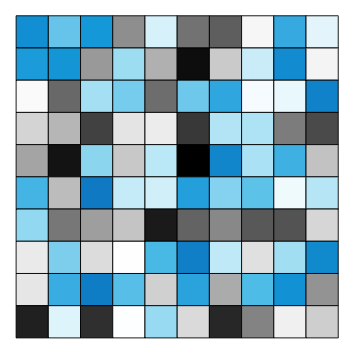

Our main goal is to develop a set of useful skills in analyzing real-world data and conducting reproducible research. Upon completing this course, you will be able to read, transform, analyze, and visualize data of various types. Many interactive exercises will allow students to check their understanding, monitor their progress, and practice their skills.

## Requirements

Attending class, continuos preparation (by working through the current chapter *before* coming to class), and solving and submitting weekly programming assignments (WPAs, see Assessment), and final exam OR project.

This course assumes some basic familiarity with statistics and the [R](http://www.r-project.org/) programming language, but enthusiastic programming novices are also welcome.

## Assessment

A. Submitting solutions to weekly programming assignments (WPAs) to [Ilias](https://ilias.uni-konstanz.de/ilias/goto_ilias_uni_crs_809936.html) by **Thursday** of the same week (by 23:59) on at least 8 out of 10 weeks.

B. Final assessment: **Vote** for 1 of 2 options:

1. Final *exam* (on Monday, 15.07.2019: 90 mins, open book);
2. Final [data science project](http://rpository.com/ds4psy/essentials/ds_project.html) (may be thesis-related, contents to be discussed with instructor).

Final grades are based on your solutions to WPAs (A: 33%) and your final exam/project (B: 67%).

# Schedule

## Individual sessions, dates, and topics

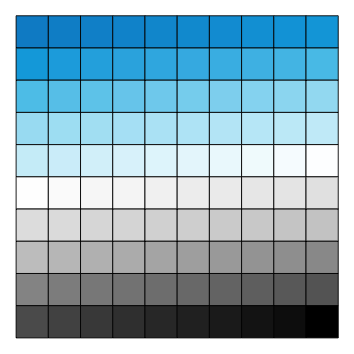

**Part 0: Preambulations**

1. 15.04.2019: **Introduction** and [r4ds Chapters 1 & 2](http://r4ds.had.co.nz).
2. 29.04.2019: **Basic R concepts and commands** and [r4ds Chapters 4/6/8](http://r4ds.had.co.nz).  
   [ds4psy](https://bookdown.org/hneth/ds4psy/): [Chapter 1: Basic R concepts and commands](https://bookdown.org/hneth/ds4psy/1-basics.html) (Exercises to be submitted on [Ilias](https://ilias.uni-konstanz.de/ilias/goto_ilias_uni_crs_863036.html) by 02.05.2019).

**Part 1: Explore data**

3. 06.05.2019: [Chapter 3: Data visualisation](http://r4ds.had.co.nz/data-visualisation.html): `ggplot2`.  
   Essentials in [ds4psy](https://bookdown.org/hneth/ds4psy/): [Chapter 2: Visualizing data](https://bookdown.org/hneth/ds4psy/2-visualize.html).  
   (Exercises to be submitted on [Ilias](https://ilias.uni-konstanz.de/ilias/goto_ilias_uni_crs_863036.html) by 09.05.2019).
4. 13.05.2019: [Chapter 5: Data transformation](http://r4ds.had.co.nz/transform.html): `dplyr`.
5. 20.05.2019: [Chapter 7: Exploratory data analysis (EDA)](http://r4ds.had.co.nz/exploratory-data-analysis.html): `dplyr` & `ggplot2`.

**Part 2: Wrangle data**

6. 27.05.2019: [Chapter 10: Tibbles](http://r4ds.had.co.nz/tibbles.html): `tibble`.
7. 03.06.2019: [Chapter 11: Data import](http://r4ds.had.co.nz/data-import.html): `readr`.
8. 17.06.2019: [Chapter 12: Tidy data](http://r4ds.had.co.nz/tidy-data.html): `tidyr`.
9. 24.06.2019: [Chapter 13: Relational data](http://r4ds.had.co.nz/relational-data.html): `dplyr`.

**Part 3: Program**

10. 01.07.2019: [Chapter 19: Functions](http://r4ds.had.co.nz/functions.html).
11. 08.07.2019: [Chapter 21: Iteration](https://r4ds.had.co.nz/iteration.html): Loops and `purrr`.
12. 15.07.2019: Starting your [data science project](http://rpository.com/ds4psy/essentials/ds_project.html) or **final exam**.

## Orientation

The following diagrams provide a schematic overview of our course curriculum (and display the same information in 2 different ways):

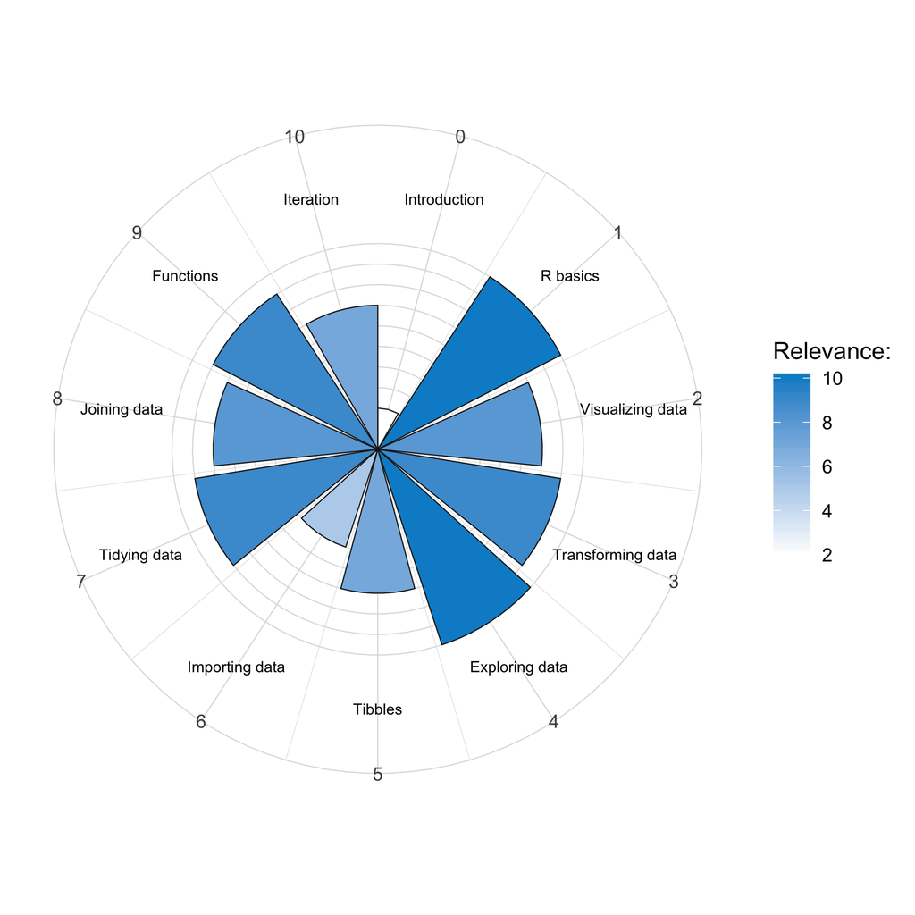

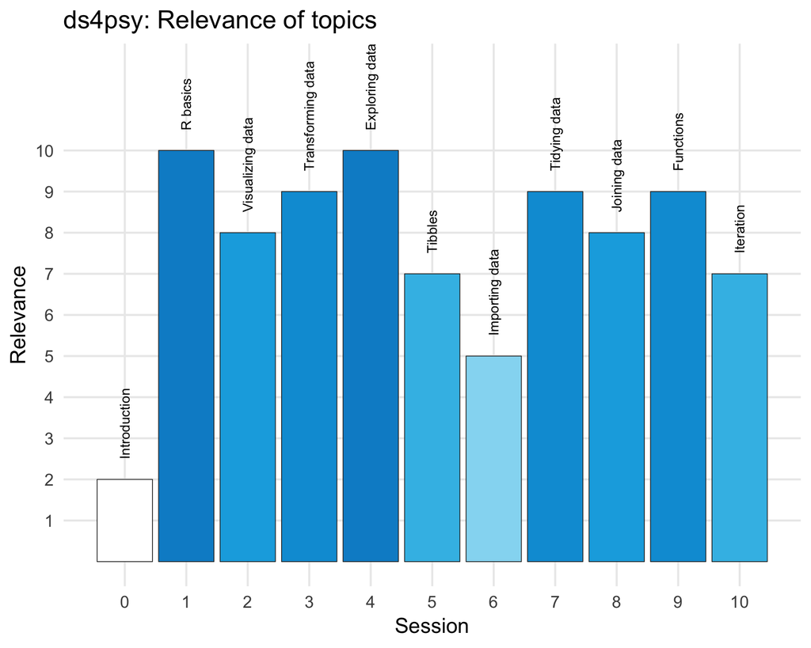

## Structure of each week and session

This course mostly uses the so-called *flipped classroom* paradigm, in which students are solving exercises — in pairs or small groups — with additional guidance by the instructor (see [Wikipedia](http://en.wikipedia.org/wiki/Flipped_classroom) for details).

- *Before* class: You need to prepare every session at home by
  1. reading the current chapter, and
  2. preparing an `.R` or `.Rmd` script that includes all chapter code (*without* the exercises).
- *During* class: Every class session consists of 2 parts:
  1. Asking questions (plenary): To start each weekly session, the instructor introduces the current topic and answers questions on main concepts or commands.
  2. Begin with weekly exercises (in random dyads/triples): Copy exercises into your script and solve them in a way that you can discuss/share with other members of the class.
- *After* class: Finish exercises at home and submit your solutions to [Ilias](https://ilias.uni-konstanz.de/ilias/goto_ilias_uni_crs_809936.html) by **Thursday** of the same week (23:59).

# Details

This section contains some clarifications (on the term “data science”) and recommendations (on how to succeed in this course).

## What is data science?

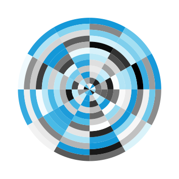

> It is a capital mistake to theorize before one has data.  
> Arthur Conan Doyle (1891): *A Scandal in Bohemia*

### Data science as the art of dealing with data

In our technology-driven environment, data is cheap and ubiquitous. Every call, trip, or visit of a web page leaves a trail of data. Apart from raising important issues of privacy, the notion of big data highlights another problem: In an era in which digital information is collected everywhere, we are drowning in data that promises to be meaningful and valuable, but we often fail to understand. We typically lack the ability and the tools of dealing with data.

Thus, data science is relevant not only for natural and computer sciences, but also for social sciences, humanities, and even arts. It is partly a scientific enterprise, but also a skill, an art, and a craft. Like all skills, arts and crafts, data science requires special tools, experience in choosing and using them, and an awful lot of dedicated practice (see below).

### Data science vs. statistics

There is considerable overlap between data science and statistics, but they are not identical.

- *Statistics* is primarily a mathematical discipline that examines the properties of probabilty distributions and inferences from samples. Statistics typically involves formulas and numbers, but does not necessarily require getting your hands dirty with real-world data. In the context of psychology, statistics mostly quantifies differences and relationships between groups and tests effects of experimental manipulations or treatments.
- *Data science* typically begins with messy data from real-world sources. Data literacy (as a basic ability to deal with data) is an essential prerequisite for applying statistics, but does not require statistics to yield meaningful results. Data science can be described as using statistics to solve real-world problems, but pursues a different main goal: understanding the data, rather than testing effects.

In short, statistics mostly summarizes data to test hypotheses, while data science transforms and visualizes data to promote the generation of hypotheses.[^1] In science, both objectives are ubiquitous and complementary, but basic data literacy and data science enable us to understand and deal with data before and beyond statistics. Dealing with data in a variety of ways enables new insights (e.g., by visualizing properties and relationships) and allows us to think more clearly about the causes and implications of data.

## Premises of this course

### Assumptions

This course assumes that you are motivated to learn its material and willing and able to invest the effort and time required to do so. Theoretically, you could work through the textbook by yourself, but this would be a tenacious and lonely endeavour. Thus, the instructor and other classmates are there to help you to stay focused, provide motivation and guidance, ask and answer questions, and allow you to continuously check your progress and understanding.

### Succeeding in this course

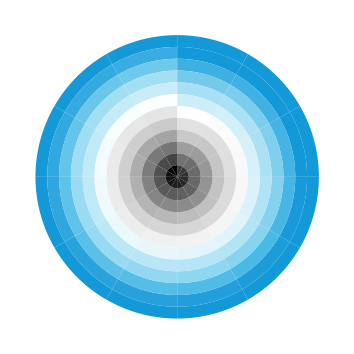

The main ingredient for succeeding in this course is sustained focus and a keen attention to detail, as aptly summarized by the following quote:

> Practise yourself (…) in little things,  
> and thence proceed to greater.  
> Epictetus *Discourses* Book I, 18

Beginning to do data science is similar to learning an instrument or mastering some sport: You first need some basic infrastructure – equipment (like hard- and software), plus training materials – to get started. Once the basics are in place, you may benefit from the advice of experts and peers, but mostly need a lot of practice. Being interested and having talent usually helps, but *dedicated practice* is essential even when you happen to be a genius.

Getting good at data science requires both *curiosity* and *routine*:

- *Curiosity* implies interest, motivation, and fun: If you really want to find out or achieve something (e.g., understand some data or conduct some analysis), you are willing to find out how this can be achieved and will overcome the obstacles that may appear along the way. Perceiving tasks as a challenge rather than a chore will allow you to enjoy the efforts invested, rather than suffering from them.
- *Routine* implies discipline, stamina, and lots of practice. It’s impossible to acquire new skills without investing time and effort. Crucially, *habitual* practice (e.g., daily use of data science tools) helps developing various organizational skills (e.g., using keyboard shortcuts, naming objects, formatting code, and structuring files or projects) that are non-trivial and will profoundly affect your productivity (far beyond this course).

Ultimately, practicing any art, craft or science is also a *process* of *socialization*: Striving towards common goals and belonging to a community that shares similar methods, principles, and values.

### Warning

Beware of side effects: Becoming an R user (useR?) will profoundly transform your thinking — not just about data and code, but about the problems you are trying to solve and understand. While programming (in R or any other language) can be enjoyable, but also has addictive potential. Make sure to take regular breaks and keep focused on the questions and science behind and beyond the data and the tools.

# Links

## Course

- Current [course syllabus](http://rpository.com/ds4psy/) (i.e., this file).
- [ZeUS](https://zeus.uni-konstanz.de:443/hioserver/pages/startFlow.xhtml?_flowId=detailView-flow&unitId=5101&periodId=179&navigationPosition=hisinoneLehrorganisation,examEventOverviewOwn)
- [Ilias](https://ilias.uni-konstanz.de/ilias/goto_ilias_uni_crs_863036.html)

All [ds4psy](http://rpository.com/ds4psy/) essentials are available at https://bookdown.org/hneth/ds4psy/.

## R Markdown

For instructions on combining text and code, see [Chapter 27: R Markdown](https://r4ds.had.co.nz/r-markdown.html) of our textbook, or use one of the following templates:

- minimal template: `rmd_template_s` [in .Rmd | .html format]
- medium template: `rmd_template_m` [in .Rmd | .html format]
- explicit explanations: `Rmarkdown_basics` [in .Rmd | .html format]

## Software and packages

- [The R project for statistical computing](http://www.r-project.org/);
- [R Studio](http://www.rstudio.com/) is an integrated development environment (IDE) for R;
- [R Markdown](https://rmarkdown.rstudio.com/) allows weaving text and code into reproducible research documents;
- The [tidyverse site](https://www.tidyverse.org/) also links to [instructional resources](https://www.tidyverse.org/learn/).

## Textbook

- Wickham, H., & Grolemund, G. (2017). *R for data science: Import, tidy, transform, visualize, and model data.* Sebastopol, Canada: O’Reilly Media, Inc. [Available online at http://r4ds.had.co.nz.]
- Essentials are available at https://bookdown.org/hneth/ds4psy/.

## References

- Donoho, D. (2017). 50 years of data science. *Journal of Computational and Graphical Statistics*, *26*(4), 745–766. [Available at https://doi.org/10.1080/10618600.2017.1384734.]
- Wickham, H. (2014). Tidy data. *Journal of Statistical Software*, *59*(10), 1–23. [Available from http://vita.had.co.nz/articles.html.]

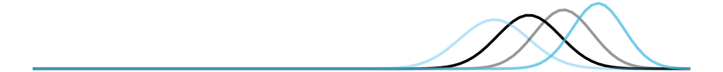

[This file last updated on 2019-05-03 20:12:23 by [hn](http://neth.de/).]

[^1]: See Donoho (2017) and related posts for a more nuanced and informed discussion.